# 课堂实验 - 基本的图像操作和处理

你可以利用 PIL (Python Imaging Library, 图像处理类库)进行图像操作，比如图像缩放、裁剪、旋转、颜色转换等。

Matplotlib 是一个绘图库，具有比 PIL 更强大的绘图功能，Matplotlib 中的 PyLab 接口包含很多方便用户创建图像的函数。

## 实验1

利用 PIL 中的 Python 模块读取一张图片，然后讲其转换成灰度图像，并使其显示。

**注意：image.jpeg 图像仅为示例，请选择一张自己的新图像作为本次作业的输入图像**

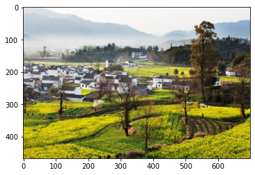

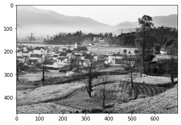

```python
# 引入实验需要的库
from PIL import Image
from pylab import imshow, figure

# 设置以内联的形式显示 matplotlib 绘制的图片（在 Notebook 中显示更美观）
%matplotlib inline

# 使用 Image.open(path) 读取你电脑中的一张图片
path = './image.jpeg'  # 需要打开的图像的路径，请更改为自己图像的路径
pil_im = Image.open(path)

figure()
imshow(pil_im)
# 使用 convert('L') 方法将其转换为灰度图像，
# 事实上 convert() 方法有更多的用途，你可以在上面提示信息的链接中获取更多信息。
pil_im_l = pil_im.convert('L')

# 显示经过处理后的灰度图片
figure()
imshow(pil_im_l, cmap='gray')
```

## 实验 2 - 对图像的简单处理

使用 PIL 中的 thumbnail() 方法可以很方便的创建图像的缩略图，它接受一个指定生成缩略图大小的二元元组。

你需要创建一个缩略图，并使其显示; 然后使用 crop() 方法从一副图像中裁剪指定区域，再将裁减的区域使用 transpose() 方法选择 180 度，最后用 paste() 方法将旋转后的区域放回原图并使其显示。

**提示**：

- 旋转 180 度时，可能要用到 Image.ROTATE_180 这一预定义常量
- 你也可以使用 resize, rotate 方法完成这个实验

```python
pil_im.thumbnail((32, 32))
figure(dpi=30)
imshow(pil_im)
```

[output not shown]

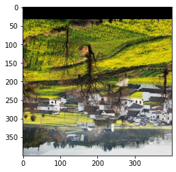

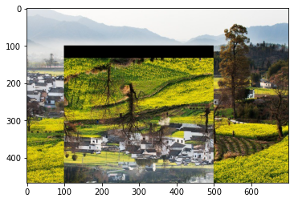

```python
# thubmnail(), paste() 等方法会直接修改对象本身，在进行下面的操作之前，需要重新获取图片
pil_im = Image.open(path)

# TODO
box = (100, 100, 500, 500) # box 为一个代表（左，上，右，下）的四元组
region = pil_im.crop(box) # 进行裁剪
region = region.transpose(Image.ROTATE_180)
# region = region.rotate(180)
figure()
imshow(region)

pil_im.paste(region, box)
##
figure()
imshow(pil_im)
```

## 实验 3 - 图像轮廓和直方图

图像用 NumPy 数组表示后，我们可以对它们执行任意数学操作。如果你的电脑里没有 NumPy，可以在Anaconda终端中输入conda install numpy或者pip install numpy进行安装。

因为绘制轮廓需要对每个坐标[x, y]的像素值施加同一个阈值，所以首先要将图像灰度化：

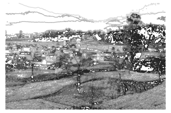

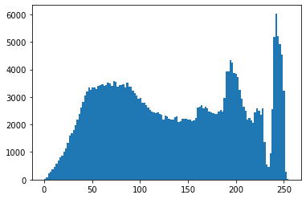

```python
from pylab import figure, gray, contour, axis, hist, show
from numpy import array

im = array(pil_im_l) #使用实验 1 的结果
# 新建一个图像
figure()
# 不使用颜色信息
gray()
# 在原点的左上角显示轮廓图像
contour(im, origin='image')
axis('equal')
axis('off')

figure()
hist(im.flatten(), 128)
show()
```

## 实验 4 - 灰度变换

在这个实验中，你需要先将图像读入 NumPy 数组（可参考实验 3），然后构造不少于一个映射，将 0...255 区间（或者 0...1 区间）映射到自身（即输出区间范围和输入区间范围相同）。

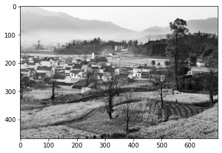

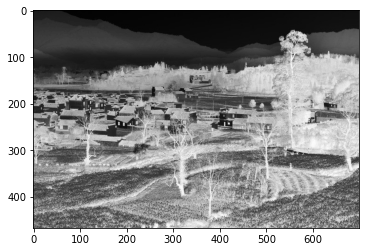

```python
# 灰度变换举例
figure()
imshow(im)

# 颜色反转
im2 = 255 - im

figure()
imshow(im2)
```